# Labour force analysis by industry

# Public Administration and Safety

*Last updated on 2020-09-19.*

A total of 822,855 individuals were employed in Public Administration and Safety in Feb 2020, before the onset of COVID-19 spread in Australia.

A total of 849,417 individuals were employed in the most recent quarter of May 2020, which is an increase of 3.23 percentage points since Feb 2020.

## Change in employment growth/decline

We can visualise the change in employment for Public Administration and Safety compared to all other industries as the rate of employment growth or decline since Nov 1984.

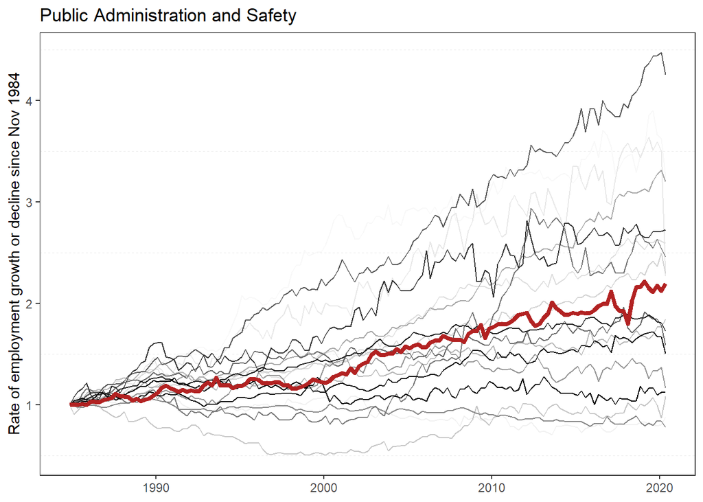

## Number of employed persons over time

We can visualise the total number of employed persons for Public Administration and Safety since Nov 1984.

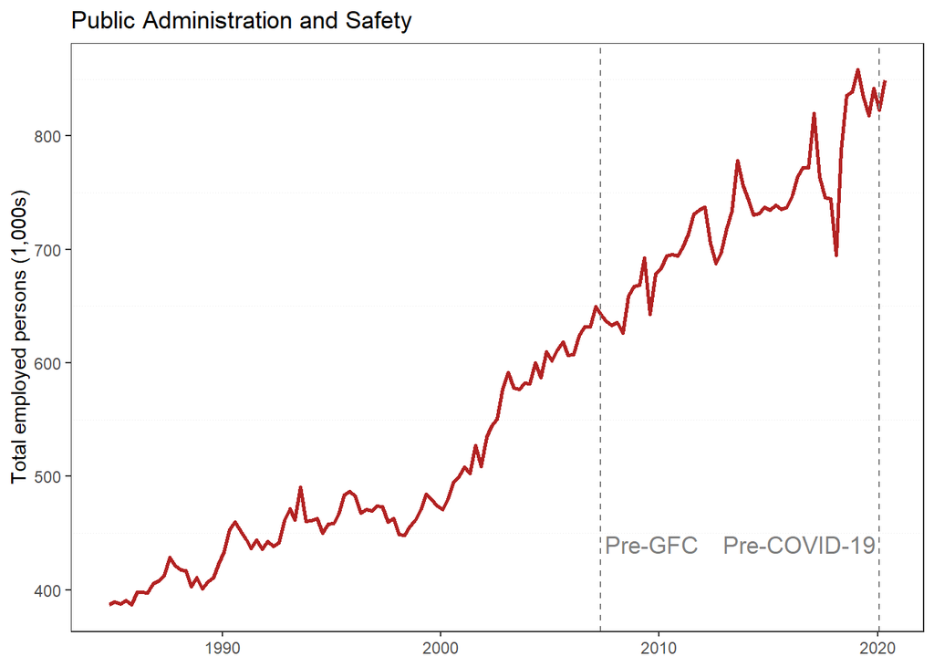

## Changes in total persons employed over time

If we subtract the employed persons count by the preceding quarter’s count, we can obtain the total increase or decreased in employment numbers. This visualisation allows us to compare how much employment numbers have fluctuated over time between different industries.

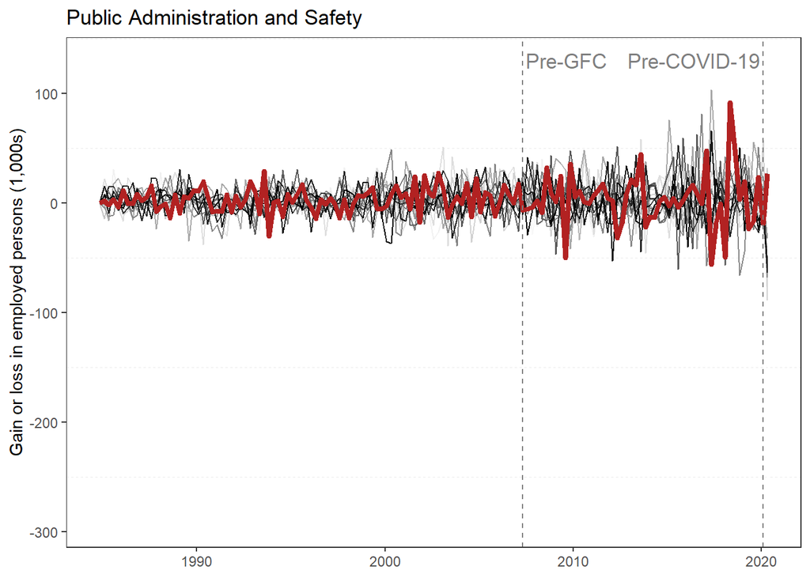

**Note**: The trend for Public Administration and Safety is highlighted in red.